# Regularized and Sparse Generalized Canonical Correlation Analysis : user manual

2018-12-05

## 1. Load the inputs

### Load the blocks

The blocks are loaded with the function `setBlocks`. The first argument of this function (`superblock`) required a bolean giving the presence (TRUE) / absence (FALSE) of a superblock. The second one corresponds to a character giving the list of the file path separated by a comma (argument `file`). By default, the name of the blocks correspond to those of the files (`names` argument) adn could be set. By default, the tabulation is used as a column separator (`sep` argument) and the first row is considered as a header (`header` parameter).

```r
# A boolean giving the presence (TRUE) / absence (FALSE) of a superblock
SUPERBLOCK =  TRUE

blocks = setBlocks(superblock = SUPERBLOCK,
                   file = "data/agriculture.tsv,data/industry.tsv,data/politic.tsv")
```

### Load the groups of response and the connection between blocks

The connection between the blocks will be used by the RGCCA and must be set by `setConnection` function. A group of samples will be used to color them in the samples plot and must be set by `setResponse` function. For both functions, the `blocks` parameter, set at the previous step, is required. The other parameters are optionals. The user could import a file containing either (`file` parameter) : (i) a symmetric matrix with 1 giving a connection between two blocs, or 0 otherwise; (ii) a univariate vector (qualtitative or quantitative) or a disjonctive table for the response. By default, the column separator is the tabulation and could be set (`sep` argument). For the `setResponse`, a header could be specified (`header` parameter).

```r
# Optional parameters
RESPONSE = "data/response.tsv"
CONNECTION = "data/connection.tsv"
# uncomment the parameters below to try without default settings
# RESPONSE <- CONNECTION <- NULL

response = setResponse(blocks = blocks,
                       file = RESPONSE)
connection = setConnection(blocks = blocks,
                           file = CONNECTION)
```

### View the inputs

agriculture

|  | gini | farm | rent |
| --- | --- | --- | --- |
| **Argentina** | 86.3 | 98.2 | 3.52 |
| **Australia** | 92.9 | 99.6 | 3.27 |
| **Austria** | 74 | 97.4 | 2.46 |
| **Belgium** | 58.7 | 85.8 | 4.15 |
| **Bolivia** | 93.8 | 97.7 | 3.04 |
| **Brasil** | 83.7 | 98.5 | 2.31 |

industry

|  | gnpr | labo |
| --- | --- | --- |
| **Argentina** | 5.92 | 3.22 |
| **Australia** | 7.1 | 2.64 |
| **Austria** | 6.28 | 3.47 |
| **Belgium** | 6.92 | 2.3 |
| **Bolivia** | 4.19 | 4.28 |
| **Brasil** | 5.57 | 4.11 |

politic

|  | inst | ecks | death | demostab | demoinst | dictator |
| --- | --- | --- | --- | --- | --- | --- |
| **Argentina** | 0.07 | 4.06 | 5.38 | 0 | 1 | 0 |
| **Australia** | 0.01 | 0 | 0 | 1 | 0 | 0 |
| **Austria** | 0.03 | 1.61 | 0 | 0 | 1 | 0 |
| **Belgium** | 0.45 | 2.2 | 0.69 | 1 | 0 | 0 |
| **Bolivia** | 0.37 | 3.99 | 6.5 | 0 | 0 | 1 |
| **Brasil** | 0.45 | 3.91 | 0.69 | 0 | 1 | 0 |

response

| **Argentina** | demoinst |
| --- | --- |
| **Australia** | demostab |
| **Austria** | demoinst |
| **Belgium** | demostab |
| **Bolivia** | dictator |
| **Brasil** | demoinst |

connection

| 0 | 0 | 0 | 1 |
| --- | --- | --- | --- |
| 0 | 0 | 0 | 1 |
| 0 | 0 | 0 | 1 |
| 1 | 1 | 1 | 0 |

## 2. Run S/RGCCA

```r
# Use two component in RGCCA to plot in a bidimensionnal space
NB_COMP = c(2, 2, 3, 3)

sgcca.res = sgcca(A = blocks,
                  C = connection,
                  ncomp = NB_COMP)

# Renames the elements of the list according to the block names
names(sgcca.res$a) = names(blocks)
```

## 3. Vizualise the analysis

Both the samples and the variables could be vizualized by using biplots functions (respectively `plotSamplesSpace` and `plotVariablesSpace`). Histograms are used to vizualized in decreasing order the variables with the higher weights and the blocks with the higher Average Variance Explained (AVE).

```r
COMP1 = 2
COMP2 = 3
NB_MARK = 100
```

### With the superblock, by default on the first and the second components

##### Samples plot

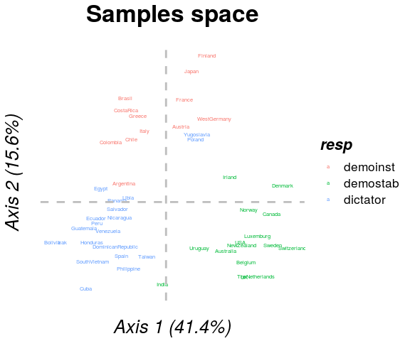

```r
plotSamplesSpace(rgcca = sgcca.res,
                 resp = response)
```

##### Corcircle plot

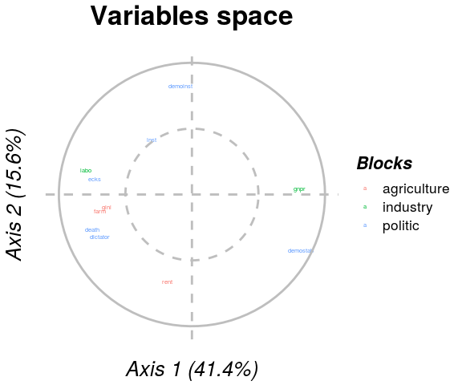

```r
plotVariablesSpace(rgcca = sgcca.res,
                   block = blocks,
                   superblock = SUPERBLOCK)
```

##### Fingerprint plot

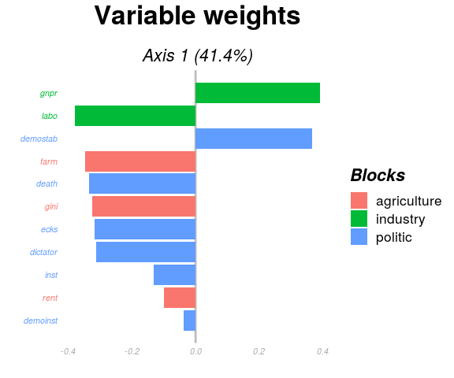

```r
plotFingerprint(rgcca = sgcca.res,
                superblock = SUPERBLOCK,
                n_mark = NB_MARK)
```

##### Best explained blocks

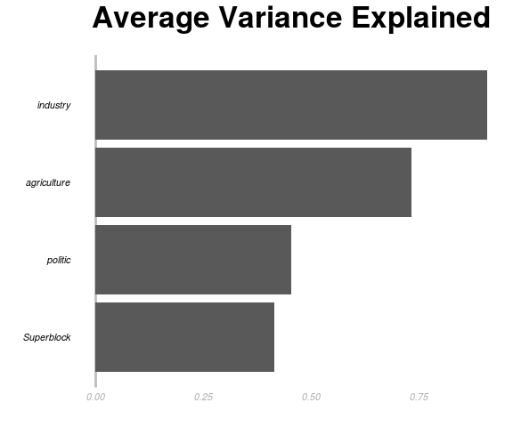

```r
plotAVE(rgcca = sgcca.res)
```

### With the politic block, on the 2nd and the 3rd components

##### Samples plot

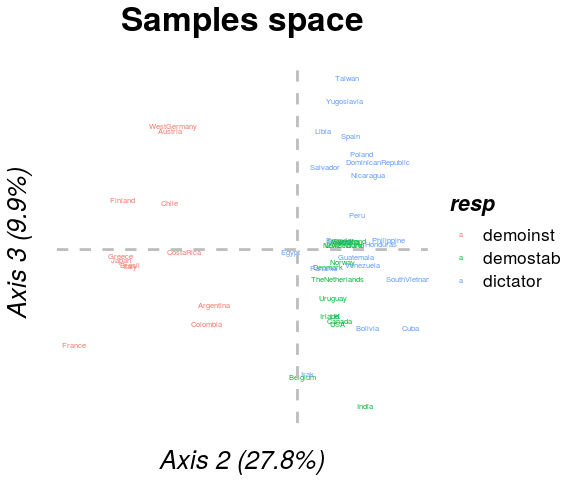

```r
plotSamplesSpace(rgcca = sgcca.res,
                 resp = response,
                 comp_x = COMP1,
                 comp_y = COMP2,
                 i_block = 3)
```

##### Corcircle plot

[figure not shown]

```r
plotVariablesSpace(rgcca = sgcca.res,
                   block = blocks,
                   comp_x = COMP1,
                   comp_y = COMP2,
                   i_block = 3)
```

##### Fingerprint plot

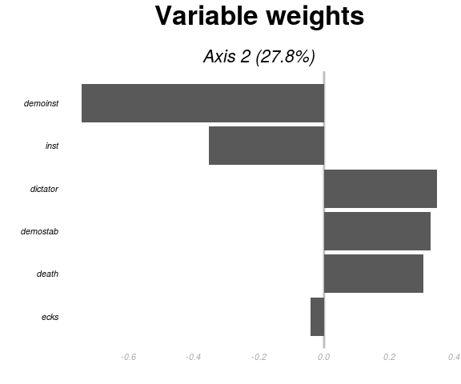

```r
plotFingerprint(rgcca = sgcca.res,
                comp = COMP1,
                n_mark = NB_MARK,
                i_block = 3)
```